# Introduction to R - Abridged, Session 2

Rockefeller University, Bioinformatics Resource Centre

http://rockefelleruniversity.github.io/RU_introtoR_abridged/

# Introduction to R (part 2)

## Overview

- [Reading and writing in R](https://rockefelleruniversity.github.io/RU_introtoR_abridged/presentations/singlepage/introToR_Session2.html#reading-and-writing-data-in-r)
- [Ordering, selecting and merging](https://rockefelleruniversity.github.io/RU_introtoR_abridged/presentations/singlepage/introToR_Session2.html#Ordering,_selecting_and_merging)
- [Conditions and Loops](https://rockefelleruniversity.github.io/RU_introtoR_abridged/presentations/singlepage/introToR_Session2.html#Conditions_and_Loops)
- Plotting

# Reading and Writing Data

## Data from external sources

Most of the time, you will not be generating data in R but will be importing data from external files.

A standard format for this data is a table:

| Gene_Name | Sample_1.hi | Sample_2.hi | Sample_3.hi |
| --- | --- | --- | --- |
| Gene_a | 3.246166 | 2.870964 | 3.572678 |
| Gene_b | 2.759227 | 2.734914 | 4.042756 |
| Gene_c | 4.423293 | 2.349322 | 3.940265 |
| Gene_d | 3.657753 | 4.797010 | 4.606233 |
| Gene_e | 10.413732 | 11.695097 | 10.084415 |
| Gene_f | 9.402434 | 9.680749 | 10.386515 |
| Gene_g | 9.276792 | 10.523490 | 8.947378 |
| Gene_h | 10.805977 | 10.766365 | 9.230518 |

## First we need a file to read in

Hopefully you’ve downloaded the [course material](https://github.com/rockefelleruniversity/Intro_To_R_1Day/zipball/master), there’s a table in it. Once the course material is unzipped we need to change our *working directory* into the downloaded folder. This is the viewpoint from which we R can see the files in your computer.

You can use *getwd()* to check your current working directory. *dir()* shows you what folders are in the directory. And *setwd()* allows you to change the working directory.

```r
getwd()
dir()
setwd("~/Downloads/RockefellerUniversity-Intro_To_R/r_course")
```

## Data from text file with read.table()

Tables from text files can be read with **read.table()** function

```r
Table <- read.table("data/readThisTable.csv",sep=",",header=T)
Table[1:4,1:3]
```

```
##   Gene_Name Sample_1.hi Sample_2.hi
## 1    Gene_a    4.570237    3.230467
## 2    Gene_b    3.561733    3.632285
## 3    Gene_c    3.797274    2.874462
## 4    Gene_d    3.398242    4.415202
```

Here we have provided two arguments. - **sep** argument specifies how columns are separated in our text file. (“,” for .csv, “ for .tsv) - **header** argument specifies whether columns have headers.

## Row names in read.table()

read.table() allows for significant control over reading files through its many arguments. Have a look at options by using **?read.table**

The **row.names** argument can be used to specify a column to use as row names for the resulting data frame. Here we use the first column as row names.

```r
Table <- read.table("data/readThisTable.csv",sep=",",header=T,row.names=1)
Table[1:4,1:3]
```

```
##        Sample_1.hi Sample_2.hi Sample_3.hi
## Gene_a    4.570237    3.230467    3.351827
## Gene_b    3.561733    3.632285    3.587523
## Gene_c    3.797274    2.874462    4.016916
## Gene_d    3.398242    4.415202    4.893561
```

## Data from other sources

The read.table function can also read data from http.

```r
URL <- "http://rockefelleruniversity.github.io/readThisTable.csv"
Table <- read.table(URL,sep=",",header=T)
Table[1:2,1:3]
```

```
##   Gene_Name Sample_1.hi Sample_2.hi
## 1    Gene_a    4.111851    3.837018
## 2    Gene_b    6.047822    5.683518
```

## Writing data to file

Once we have our data analysed in R, we will want to export it to a file.

The most common method is to use the write.table() function

```r
write.table(Table, file="data/writeThisTable.csv", sep=",")
```

Since our data has column names but no row names, I will provide the arguments col.names and row.names to write.table()

```r
write.table(Table, file="data/writeThisTable.csv", sep=",", row.names =F, col.names=T)
```

# Reviewing your data

It is always important to know what your data is. Especially when you are reading it in for the first time. We have used indexing to get a taste of the data frames so far. But there are two functions to quickly check your data. **head()** and **tail()** return the first or last 6 lines by default.

```r
head(Table)
```

```
##   Gene_Name Sample_1.hi Sample_2.hi Sample_3.hi Sample_4.low Sample_5.low
## 1    Gene_a    4.111851    3.837018    4.360628     3.752517     4.368069
## 2    Gene_b    6.047822    5.683518    4.315889     3.381136     3.630273
## 3    Gene_c    2.597068    3.316300    3.681509     4.886520     4.318289
## 4    Gene_d    6.009197    5.927419    2.244701     6.574108     8.288831
## 5    Gene_e   10.152509   10.218200   10.004835     2.251603     1.805168
## 6    Gene_f   11.107868    9.592153   10.263975     3.567560     2.496475
##   Sample_1.low
## 1     3.421009
## 2     5.560802
## 3     5.097783
## 4     6.857291
## 5     2.396295
## 6     3.587755
```

# Reviewing your data

```r
tail(Table)
```

```
##   Gene_Name Sample_1.hi Sample_2.hi Sample_3.hi Sample_4.low Sample_5.low
## 3    Gene_c    2.597068    3.316300    3.681509     4.886520     4.318289
## 4    Gene_d    6.009197    5.927419    2.244701     6.574108     8.288831
## 5    Gene_e   10.152509   10.218200   10.004835     2.251603     1.805168
## 6    Gene_f   11.107868    9.592153   10.263975     3.567560     2.496475
## 7    Gene_g    8.705787    8.949422    9.226990    10.051516     7.841664
## 8    Gene_h    9.239039    9.839734   10.027812    11.084444     9.316200
##   Sample_1.low
## 3     5.097783
## 4     6.857291
## 5     2.396295
## 6     3.587755
## 7     9.649869
## 8     8.742943
```

```r
head(Table, 3)
```

```
##   Gene_Name Sample_1.hi Sample_2.hi Sample_3.hi Sample_4.low Sample_5.low
## 1    Gene_a    4.111851    3.837018    4.360628     3.752517     4.368069
## 2    Gene_b    6.047822    5.683518    4.315889     3.381136     3.630273
## 3    Gene_c    2.597068    3.316300    3.681509     4.886520     4.318289
##   Sample_1.low
## 1     3.421009
## 2     5.560802
## 3     5.097783
```

## The rio (R io) package

We may want to import from formats other than plain text.

We can make use of an R package (the rio package) which allows us to import and export data to mulitple formats.

Formats include:

- XML.
- Matlab, SAS, SPSS and minitab output formats.
- Excel and OpenOffice formats.

## The rio package

To make use of the rio package functionality we will need to install this package to our version of R.

We can do this by using the **install.packages()** function with the package we wish to install.

**install.packages(*PACKAGENAME*)**

```r
install.packages("rio")
```

## The rio package

Once we have installed a package, we will need to load it to make the functions available to us.

We can load a library by using the **library()** function with package we wish to install

**library(*PACKAGENAME*)**

```r
library("rio")
```

## The rio package

The main two functions in the rio package are the **import** and **export** functions.

We can use the **import()** function to read in our csv file. We simple specify our file as an argument to the **import()** function.

**import(*Filename*)**

```r
Table <- import("data/readThisTable.csv")
Table[1:2,]
```

```
##   Gene_Name Sample_1.hi Sample_2.hi Sample_3.hi Sample_4.low Sample_5.low
## 1    Gene_a    4.570237    3.230467    3.351827     3.930877     4.098247
## 2    Gene_b    3.561733    3.632285    3.587523     4.185287     1.380976
##   Sample_1.low
## 1     4.418726
## 2     5.936990
```

## The rio package

By default we will only retrieve the first sheet.

We can specify the sheet by name or number using the **which** argument.

```r
Table <- import("data/readThisXLS.xls",
                which=2)
Table <- import("data/readThisXLS.xls",
                which="Metadata")
Table[1:2,]
```

```
##       Patient Condition   Treatment
## 1 Sample_1.hi         A           X
## 2 Sample_2.hi         A NoTreatment
```

## The rio package

We can export our data back to file using the **export()** function and specifying the name of the output file to the **file** argument. The **export()** function will guess the format required from the extension.

```r
ExpressionScores <- Table$ExpressionScores
export(ExpressionScores, file = "data/writeThisXLSX.xlsx")
```

# Ordering, selecting and merging

## Working with your data

Data analysis typically starts when you want to start performing operations on whatever input data you have. Commonly types are:

- Ordering
- Selecting
- Merging

## Lets get some input data

```r
my_df <- read.table("data/categoriesAndExpression.txt",sep="\t",header=T)
head(my_df)
```

```
##   geneName ofInterest    pathway Expression
## 1    Gene1   Selected Glycolysis   20.09519
## 2    Gene2   Selected Glycolysis   23.00306
## 3    Gene3   Selected Glycolysis   20.99712
## 4    Gene4   Selected Glycolysis   43.01145
## 5    Gene5   Selected Glycolysis   22.00567
## 6    Gene6   Selected Glycolysis   20.99162
```

## Ordering

The order function can be used to reorder objects in R. The result of this function is the numerical order of the input, from smallest to largest.

```r
order(my_df[,4])
```

```
##   [1]  28  50  49  60  43  29  15   1  37  31  52  34   6   3   9  22  33   5
##  [19]  54  27   8  14  59  48  36  21  30   2  42  51  45  56  39  35  24  11
##  [37]   7  25  12  40  46  57  10  44  55  38  23  19  32   4  53  79  64  96
##  [55]  90  73  98  65  91  80  74  97  83  85  68  77  94  62  70  87  69  17
##  [73]  86  71  88  16  63  89  78  72  95  99  92  66  81  75  82  84  67  18
##  [91]  93 100  61  76  20  58  41  47  26  13
```

## Ordering

We can use the result of order to index our data frame. This will reorder the dataframe based on the order. In this case we are reordeing based on lowest expression.

```r
my_df_ordered <- my_df[order(my_df[,4]),]

head(my_df_ordered)
```

```
##    geneName  ofInterest    pathway Expression
## 28   Gene28 NotSelected Glycolysis   19.94369
## 50   Gene50 NotSelected Glycolysis   19.95572
## 49   Gene49 NotSelected Glycolysis   19.95703
## 60   Gene60 NotSelected Glycolysis   19.97635
## 43   Gene43 NotSelected Glycolysis   19.98250
## 29   Gene29 NotSelected Glycolysis   20.02165
```

## Ordering

```r
my_df_ordered <- my_df[order(my_df[,4], decreasing = T),]

head(my_df_ordered)
```

```
##    geneName  ofInterest    pathway Expression
## 13   Gene13    Selected Glycolysis   74.08310
## 26   Gene26 NotSelected Glycolysis   73.98877
## 47   Gene47 NotSelected Glycolysis   73.96610
## 41   Gene41 NotSelected Glycolysis   73.96022
## 58   Gene58 NotSelected Glycolysis   73.94659
## 20   Gene20    Selected       TGFb   66.09706
```

## Subsetting

Another operation we often want to do is subset our dataset based on a specific condition i.e. I want to only look at Glycolysis genes, or I only want to gene above a certain expression threshold. To do this we need to use a logical operator test to see if this if something is TRUE.

Here we see which genes have an expression greater than 70.

```r
my_df_ordered$Expression > 70
```

```
##   [1]  TRUE  TRUE  TRUE  TRUE  TRUE FALSE FALSE FALSE FALSE FALSE FALSE FALSE
##  [13] FALSE FALSE FALSE FALSE FALSE FALSE FALSE FALSE FALSE FALSE FALSE FALSE
##  [25] FALSE FALSE FALSE FALSE FALSE FALSE FALSE FALSE FALSE FALSE FALSE FALSE
##  [37] FALSE FALSE FALSE FALSE FALSE FALSE FALSE FALSE FALSE FALSE FALSE FALSE
##  [49] FALSE FALSE FALSE FALSE FALSE FALSE FALSE FALSE FALSE FALSE FALSE FALSE
##  [61] FALSE FALSE FALSE FALSE FALSE FALSE FALSE FALSE FALSE FALSE FALSE FALSE
##  [73] FALSE FALSE FALSE FALSE FALSE FALSE FALSE FALSE FALSE FALSE FALSE FALSE
##  [85] FALSE FALSE FALSE FALSE FALSE FALSE FALSE FALSE FALSE FALSE FALSE FALSE
##  [97] FALSE FALSE FALSE FALSE
```

## Logical operators

Operators that we commonly use are:

- **==** evaluates as equal.
- **>** and **<** evaluates as greater or less than respectively.
- **>=** and **<=** evaluates as greater than or equal or less than or equal respectively.

## Logical and indexing

The result of these expressions is a logical vector of TRUE/FALSE values. These vectors can be used to index, just like numerical vectors. TRUE values are returned.

```r
idx <- my_df_ordered$Expression > 70
my_df_ordered[idx,]
```

```
##    geneName  ofInterest    pathway Expression
## 13   Gene13    Selected Glycolysis   74.08310
## 26   Gene26 NotSelected Glycolysis   73.98877
## 47   Gene47 NotSelected Glycolysis   73.96610
## 41   Gene41 NotSelected Glycolysis   73.96022
## 58   Gene58 NotSelected Glycolysis   73.94659
```

## Combining logical vectors

Logical vectors can be used in combination in order to index vectors. To combine logical vectors we can use some common R operators.

- **&** - Requires both logical operators to be TRUE
- **|** - Requires either logical operator to be TRUE.
- **!** - Reverses the logical operator, so TRUE is FALSE and FALSE is TRUE.

```r
my_df_ordered[my_df_ordered$Expression > 60 & my_df_ordered$pathway == "TGFb",]
```

```
##     geneName  ofInterest pathway Expression
## 20    Gene20    Selected    TGFb   66.09706
## 76    Gene76 NotSelected    TGFb   63.08147
## 61    Gene61 NotSelected    TGFb   63.04337
## 100  Gene100 NotSelected    TGFb   62.93485
## 93    Gene93 NotSelected    TGFb   62.93153
```

## The %in% operator

A common task in R is to subset one vector by the values in another vector.

The **%in%** operator in the context **A %in% B** creates a logical vector of whether values in **A** matches any values in of **B**.

```r
my_favorite_genes <- c("Gene1","Gene10","Gene15")
logical_index <- my_df$geneName %in% my_favorite_genes
logical_index
```

```
##   [1]  TRUE FALSE FALSE FALSE FALSE FALSE FALSE FALSE FALSE  TRUE FALSE FALSE
##  [13] FALSE FALSE  TRUE FALSE FALSE FALSE FALSE FALSE FALSE FALSE FALSE FALSE
##  [25] FALSE FALSE FALSE FALSE FALSE FALSE FALSE FALSE FALSE FALSE FALSE FALSE
##  [37] FALSE FALSE FALSE FALSE FALSE FALSE FALSE FALSE FALSE FALSE FALSE FALSE
##  [49] FALSE FALSE FALSE FALSE FALSE FALSE FALSE FALSE FALSE FALSE FALSE FALSE
##  [61] FALSE FALSE FALSE FALSE FALSE FALSE FALSE FALSE FALSE FALSE FALSE FALSE
##  [73] FALSE FALSE FALSE FALSE FALSE FALSE FALSE FALSE FALSE FALSE FALSE FALSE
##  [85] FALSE FALSE FALSE FALSE FALSE FALSE FALSE FALSE FALSE FALSE FALSE FALSE
##  [97] FALSE FALSE FALSE FALSE
```

## The %in% operator

This can be then used to subset the values within one character vector by a those in a second.

```r
my_df[logical_index,]
```

```
##    geneName ofInterest    pathway Expression
## 1     Gene1   Selected Glycolysis   20.09519
## 10   Gene10   Selected Glycolysis   34.91377
## 15   Gene15   Selected Glycolysis   20.06247
```

## Merging

A common operation is to join two data frames by a column of common values.

```r
my_df2 <- read.table("data/gene_lengths.txt",sep="\t",header=T)

nrow(my_df2)
```

```
## [1] 15
```

```r
head(my_df2)
```

```
##    Gene Length
## 1 Gene1   1788
## 2 Gene3    213
## 3 Gene5    529
## 4 Gene7    234
## 5 Gene8   1638
## 6 Gene9    917
```

```r
nrow(my_df)
```

```
## [1] 100
```

## Merging data frames

To do this we can use the **merge()** function with the data frames as the first two arguments. We can then specify the columns to merge by with the **by** argument. To keep only data pertaining to values common to both data frames the **all** argument is set to FALSE.

```r
merge_df <- merge(my_df, my_df2, by.x="geneName","Gene", all=FALSE)
merge_df
```

```
##    geneName ofInterest    pathway Expression Length
## 1     Gene1   Selected Glycolysis   20.09519   1788
## 2    Gene10   Selected Glycolysis   34.91377   1882
## 3    Gene12   Selected Glycolysis   27.01314    501
## 4    Gene13   Selected Glycolysis   74.08310   1045
## 5    Gene15   Selected Glycolysis   20.06247   1869
## 6    Gene16   Selected       TGFb   56.03506    851
## 7    Gene17   Selected       TGFb   54.00140   1807
## 8    Gene18   Selected       TGFb   59.04783    600
## 9    Gene19   Selected       TGFb   42.91023   1889
## 10   Gene20   Selected       TGFb   66.09706    992
## 11    Gene3   Selected Glycolysis   20.99712    213
## 12    Gene5   Selected Glycolysis   22.00567    529
## 13    Gene7   Selected Glycolysis   26.07826    234
## 14    Gene8   Selected Glycolysis   22.92961   1638
## 15    Gene9   Selected Glycolysis   21.02250    917
```

# Conditions and Loops

## Conditions and Loops

We have looked at using logical vectors as a way to index other data types.

```r
x <- 1:10
x[x < 4]
```

```
## [1] 1 2 3
```

Logicals are also used in controlling how scripted procedures execute.

## Conditional branching

Conditional branching is the evaluation of a logical to determine whether a chunk of code is executed.

In R, we use the **if** statement with the logical to be evaluated in **()** and dependent code to be executed in **{}**.

```r
x <- 10
y <- 4
if(x > y){
  message("The value of x is ",x," which is greater than ", y)
}
```

```
## The value of x is 10 which is greater than 4
```

The message is printed above because x is greater than y.

```r
y <- 20
if(x > y){
  message("The value of x is ",x," which is greater than ", y)
}
```

x is now no longer greater than y, so no message is printed.

It would be better if all outcomes have a message. So we want a message telling us what was the result of the condition.

## else following an if

If we want to perform an operation when the condition is false we can follow the if() statement with an else statement.

```r
x <- 3
if(x < 5){
  message(x, " is less than to 5")
   }else{
     message(x," is greater than or equal to 5")
}
```

```
## 3 is less than to 5
```

With the addition of the else statement, when x is not less than 5 the code following the else statement is executed.

```r
x <- 10
if(x < 5){
  message(x, " is less than 5")
   }else{
     message(x," is greater than or equal to 5")
}
```

```
## 10 is greater than or equal to 5
```

## else if

We may wish to execute different procedures under multiple conditions. This can be controlled in R using the else if() following an initial if() statement.

```r
x <- 5
if(x > 5){
  message(x," is greater than 5")
  }else if(x == 5){
    message(x," is 5")
  }else{
    message(x, " is less than 5")
  }
```

```
## 5 is 5
```

## ifelse()

A useful function to evaluate conditional statements over vectors is the **ifelse()** function.

```r
x <- 1:10
x
```

```
##  [1]  1  2  3  4  5  6  7  8  9 10
```

The ifelse() functions take the arguments of the condition to evaluate, the action if the condition is true and the action when condition is false.

```r
ifelse(x <= 3,"lessOrEqual","more")
```

```
##  [1] "lessOrEqual" "lessOrEqual" "lessOrEqual" "more"        "more"
##  [6] "more"        "more"        "more"        "more"        "more"
```

## ifelse()

We can use multiple nested **ifelse** functions to be apply more complex logical to vectors.

```r
ifelse(x == 3,"same",
       ifelse(x < 3,"less","more")
      )
```

```
##  [1] "less" "less" "same" "more" "more" "more" "more" "more" "more" "more"
```

## Loops

The two main generic methods of looping in R are **while** and **for**

- **while** - *while* loops repeat the execution of code while a condition evaluates as true.
- **for** - *for* loops repeat the execution of code for a range of specified values.

## For loops

For loops allow the user to cycle through a range of values applying an operation for every value.

Here we cycle through a numeric vector and print out its value.

```r
x <- 1:5
for(i in x){
  message(i," ", appendLF = F)
}
```

```
## 1 2 3 4 5
```

Similarly we can cycle through other vector types (or lists).

```r
x <- toupper(letters[1:5])
for(i in x){
  message(i," ", appendLF = F)
}
```

```
## A B C D E
```

## Looping through indices

We may wish to keep track of the position in x we are evaluating to retrieve the same index in other variables. A common practice is to loop though all possible index positions of x using the expression **1:length(x)**.

```r
geneName <- c("Ikzf1","Myc","Igll1")
expression <- c(10.4,4.3,6.5)
1:length(geneName)
```

```
## [1] 1 2 3
```

```r
for(i in 1:length(geneName)){
  message(geneName[i]," has an RPKM of ",expression[i])
}
```

```
## Ikzf1 has an RPKM of 10.4
```

```
## Myc has an RPKM of 4.3
```

```
## Igll1 has an RPKM of 6.5
```

## Loops and conditionals

Loops can be combined with conditional statements to allow for complex control of their execution over R objects.

```r
x <- 1:13

for(i in 1:13){
  if(i > 10){
    message("Number ",i," is greater than 10")
  }else if(i == 10){
    message("Number ",i," is  10")
  }else{
    message("Number ",i," is less than 10")
  }
}
```

```
## Number 1 is less than  10
```

```
## Number 2 is less than  10
```

```
## Number 3 is less than  10
```

```
## Number 4 is less than  10
```

```
## Number 5 is less than  10
```

```
## Number 6 is less than  10
```

```
## Number 7 is less than  10
```

```
## Number 8 is less than  10
```

```
## Number 9 is less than  10
```

```
## Number 10 is  10
```

```
## Number 11 is greater than 10
```

```
## Number 12 is greater than 10
```

```
## Number 13 is greater than 10
```

## Functions to loop over data types

There are functions which allow you to loop over a data type and apply a function to the subsection of that data.

- **apply** - Apply function to rows or columns of a matrix/data frame and return results as a vector,matrix or list.
- **lapply** - Apply function to every element of a vector or list and return results as a list.
- **sapply** - Apply function to every element of a vector or list and return results as a vector,matrix or list.

## sapply()

**sapply** (*smart apply*) acts as lapply but attempts to return the results as the most appropriate data type.

Here sapply returns a vector where lapply would return lists.

```r
exampleVector <- c(1,2,3,4,5)
exampleList <- list(1,2,3,4,5)
sapply(exampleVector, mean, na.rm=T)
```

```
## [1] 1 2 3 4 5
```

```r
sapply(exampleList, mean, na.rm=T)
```

```
## [1] 1 2 3 4 5
```

## sapply() example

In this example lapply returns a list of vectors from the quantile function.

```r
exampleList <- list(row1=1:5,
                    row2=6:10,
                    row3=11:15)
exampleList
```

```
## $row1
## [1] 1 2 3 4 5
##
## $row2
## [1]  6  7  8  9 10
##
## $row3
## [1] 11 12 13 14 15
```

```r
lapply(exampleList, quantile)
```

```
## $row1
##   0%  25%  50%  75% 100%
##    1    2    3    4    5
##
## $row2
##   0%  25%  50%  75% 100%
##    6    7    8    9   10
##
## $row3
##   0%  25%  50%  75% 100%
##   11   12   13   14   15
```

## sapply() example 2

Here is an example of sapply parsing a result from the quantile function in a *smart* way.

When a function always returns a vector of the same length, sapply will create a matrix with elements by column.

```r
sapply(exampleList, quantile)
```

```
##      row1 row2 row3
## 0%      1    6   11
## 25%     2    7   12
## 50%     3    8   13
## 75%     4    9   14
## 100%    5   10   15
```

## sapply() example 3

When sapply cannot parse the result to a vector or matrix, a list will be returned.

```r
exampleList <- list(df=data.frame(sample=paste0("patient",1:2), data=c(1,12)),
                    vec=c(1,3,4,5))
sapply(exampleList, summary)
```

```
## $df
##     sample               data
##  Length:2           Min.   : 1.00
##  Class :character   1st Qu.: 3.75
##  Mode  :character   Median : 6.50
##                     Mean   : 6.50
##                     3rd Qu.: 9.25
##                     Max.   :12.00
##
## $vec
##    Min. 1st Qu.  Median    Mean 3rd Qu.    Max.
##    1.00    2.50    3.50    3.25    4.25    5.00
```

# Plotting

## Base plotting

Base plotting function *plot* does a good job at estimating what kind of plot you might want. The output varies depending on what type of data type is your input.

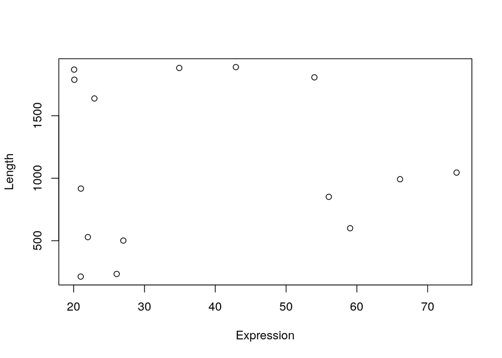

```r
plot(merge_df[,c(4,5)])
```

## Base plotting

Many plots types like factors. This helps the plotting deal with dividing your data into categories. Here we try with a regular vector.

```r
plot(merge_df[,3])
```

```
## Error in plot.window(...) : need finite 'ylim' values
```

## Base plotting

Now we try with a factor.

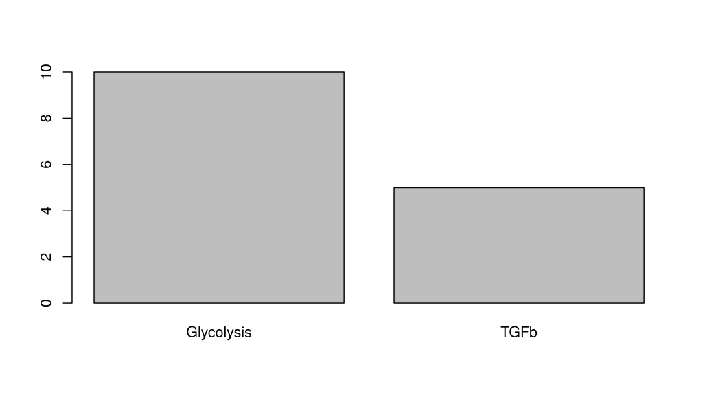

```r
merge_df[,3] <- factor(merge_df[,3])
plot(merge_df[,3])
```

## Base plotting

There are also some functions for making specific plots, like boxplot.

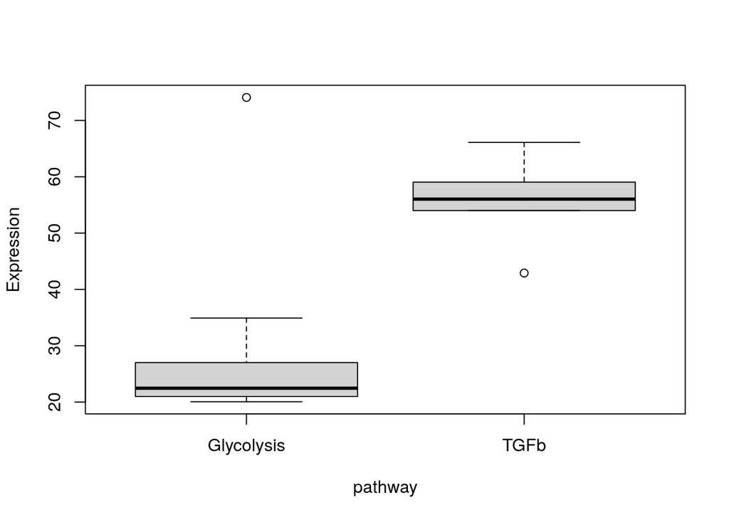

```r
boxplot(Expression ~ pathway, merge_df)
```

## Beyond Base plots

For more advance plots we recommend you check out our ggplot2 training. [R graph gallery](https://r-graph-gallery.com/index.html) is also a really useful website that has example plots and the code used to generate them.

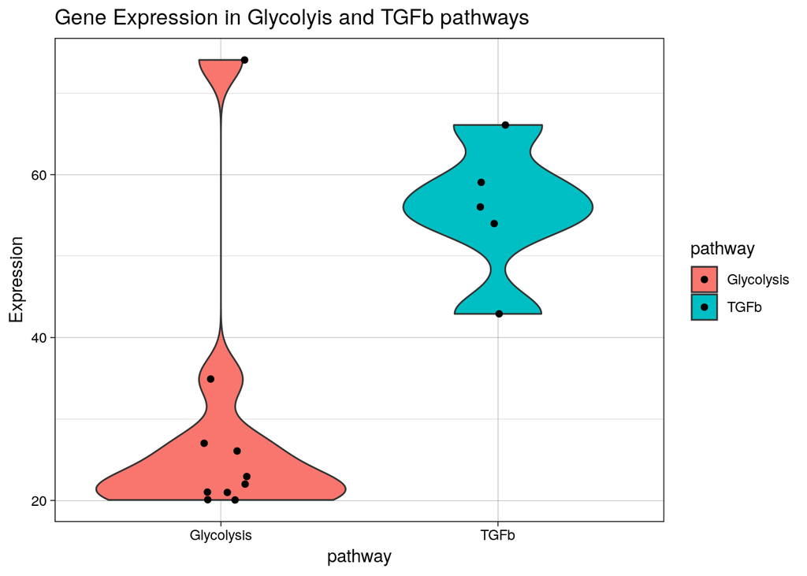

```r
library(ggplot2)

ggplot(merge_df, aes(x=pathway, y=Expression, fill=pathway))+
  geom_violin()+
  geom_jitter(width=0.1)+
  theme_linedraw()+
  ggtitle("Gene Expression in Glycolyis and TGFb pathways")
```

## What we didn’t cover

- Matrices
- [While loops](https://rockefelleruniversity.github.io/Intro_To_R_1Day/presentations/singlepage/introToR_Session2.html#While_loops)
- [Coercing data types](https://rockefelleruniversity.github.io/Intro_To_R_1Day/presentations/singlepage/introToR_Session1.html#Coercing_data_formats)
- [Custom functions](https://rockefelleruniversity.github.io/Intro_To_R_1Day/presentations/singlepage/introToR_Session2.html#Custom_functions)
- [Making scripts](https://rockefelleruniversity.github.io/Intro_To_R_1Day/presentations/singlepage/introToR_Session2.html#Scripts)

## Getting help

- From us: Raise an issue on our [GitHub](https://github.com/RockefellerUniversity/RU_introtoR_abridged/issues). This can be suggestions, comments, edits or questions (about content or the slides themselves).
- Google
- Local friendly bioinformaticians and computational biologists.
- [Stackoverflow](http://stackoverflow.com/)
- [R-help](https://stat.ethz.ch/mailman/listinfo/r-help)